# Secure Chat Burden for Infectious Disease Fellows

BMIN503/EPID600 Final Project

Author

Lauren Coogle

## Overview

For hospitalized children and their families, breakdowns in patient safety can result in long-lasting and costly harm. Communication failure is one of the most common contributors to patient safety events.<sup>1-5</sup> With the influx of new technology intended to facilitate communication between clinicians, communication workflows are drastically changing.<sup>6</sup> The Pediatric Patient Safety Learning Laboratory (PSLL) was proposed to reengineer inter-professional communication work systems using a Safety II (or, “resilient healthcare”) framework. A multidisciplinary team was established to enhance the communication work system and prevent harm to hospitalized children. Using systems engineering methodology, specific aims were established for project analysis, design, development, implementation, and evaluation.

At the current stage of this project, we are focused on conducting a problem analysis of secure chat communication used in the care of hospitalized children. Under the guidance of Dr. Chris Bonafide, Attending Physician and Dr. Austin DeChalus, Pediatric Hospital Medicine Fellow, I have done an initial subgroup analysis and used the secure chat data extracted from Epic Clarity to investigate overnight chat burden for infectious disease fellows at a single institution.

[Link to final project GitHub repository is here.](https://github.com/cooglel/BMIN503_Final_Project)

## Introduction

The infectious disease fellows have been vocal about their perceived high chat burden on overnight call shifts. Their schedules often had them working during the day, on call that night from home, and then back to work the following day. Inadequate sleep due to interruptive chats was impacting their mental health, and they feared a patient safety event would occur due to inadequate sleep.

In this exploratory data analysis, we sought to characterize secure chats to infectious disease fellows on overnight call shifts. For each evening on weekdays and weekends, a single infectious disease fellow covered call from 5 pm through 7 am. As infectious disease does not admit their own patients, all communication to them would be regarding patients for consult. By characterizing these secure chat messages, we are hoping to design and develop interventions to improve the communication work system. With this baseline analysis, we can then evaluate our interventions in the clinical environment to measure impact of changes.

With the ongoing introduction of technologies that transform how, when, and what clinicians communicate among each other in the inpatient setting, developing infrastructure to proactively evaluate these systems is more important than ever. Clinician-to-clinician communication impacts all hospitalized pediatric patients (around 2.5 million per year) and their families. Our Safety II-informed systems engineering methodology will also be translatable to other systems of care providing a template for the future of patient safety work. The data analysis below is a small but important part of this larger initiative.

## Methods

### Data

We analyzed six months worth of secure chat data, from Feb 12, 2024 through Aug 8, 2024, to evaluate communication patterns during on-call shifts for infectious disease (ID) fellows. Secure chat data is captured in Epic Clarity, a reporting database. The dataset comprised of messages sent between healthcare and administrative team members through desktop and mobile devices, including metadata fields such as sender ID, recipient ID, timestamp (converted to Eastern Standard Time), and conversation ID. A second data set with the assigned ID fellows on call was used to find the messages read for each call shift by the ID fellow on call. There was no missing or incomplete data in these data sets.

```r
#combine all ID chats from files above (hidden code) into one data frame
chats <- rbind(chats_Feb24, chats_Mar24, chats_Apr24, chats_May24, chats_Jun24, chats_Jul24)
```

The call schedule was downloaded from QGenda for the infectious disease (ID) fellows for those dates and initially manipulated in Microsoft Excel for ease of uploading and merging data sets. I confirmed with a current ID fellow that the call schedule available on QGenda, the physician scheduling platform, was accurate. For each overnight call shift, only one fellow is assigned. *Code hidden to protect fellow identities.*

Data preprocessing involved filtering chat records to include messages read by the ID fellows during their designated on-call hours (5:00 PM to 7:00 AM) and categorizing messages by call shift, rather than calendar dates.

```r
#filter to only ID fellow chats Read
chats_read <- chats |>
  as.data.frame() |>
  filter(READER_USER_ID %in% id.fellow.list) |>
  filter(SENDER_USER_ID != READER_USER_ID) |>
  mutate(READ_DATE_EST = as.Date(READ_TIME_EST)) |> #date column
  mutate(READ_HOUR_EST = format(READ_TIME_EST, format='%H')) |> #hour column, for visualizations
  select(CONTACT_DATE_REAL, CONVO_LINE, TOTAL_CHAT_SENT, READ_DATE_EST, READER_USER_ID, READ_HOUR_EST, READ_TIME_EST, READ_TIME, SENDER_USER_ID)

#filter for chats read by ID fellows between 5p-7a
chats_overnight <- chats_read |>
  filter(as.numeric(READ_HOUR_EST) < 7 | as.numeric(READ_HOUR_EST) > 16)

#add column for "ON_CALL_DATE" for ease of graphing
chats_overnight <- chats_overnight |>
  mutate(ON_CALL_DATE = if_else(
    chats_overnight$READ_HOUR_EST >= 17 & chats_overnight$READ_HOUR_EST <= 23,
    chats_overnight$READ_DATE_EST,  #use SENT_DATE_EST if the hour is between 17 and 23
    chats_overnight$READ_DATE_EST - 1  #subtract 1 day if the hour is between 00 and 06
    )
  )

#now, filter for only chat received by the user (ID fellow) on a call shift
call_sched <- read_csv("~/Documents/Masters of Biomedical Informatics/503 Data Science/Final Project/ID_call_schedule.csv")
chatsoncall <- chats_overnight |>
  inner_join(call_sched, by = c("READER_USER_ID", "ON_CALL_DATE"))
```

### Initial Exploration

Our initial exploratory analysis revealed the secure chat burden during the on call shifts. Summary statistics were also calculated.

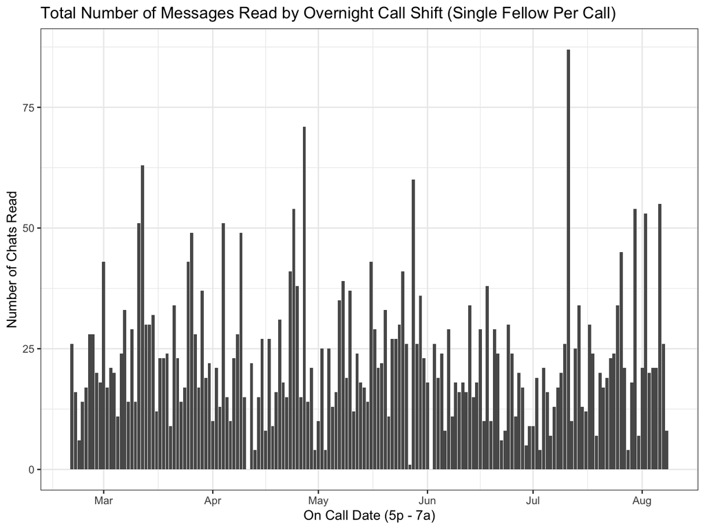

```r
#summarize by overnight call shift
chatsoncall_summ <- chatsoncall |>
  group_by(ON_CALL_DATE) |>
  summarize(number_of_chats = n())

#let's graph!!
ggplot(chatsoncall_summ, aes(x = ON_CALL_DATE, y = number_of_chats)) +
  geom_bar(stat = "identity") +
  ggtitle("Total Number of Messages Read by Overnight Call Shift (Single Fellow Per Call)") +
  labs(x = "On Call Date (5p - 7a)", y = "Number of Chats Read") +
  theme_bw()
```

```r
median(chatsoncall_summ$number_of_chats)
```

```
[1] 21
```

```r
mean(chatsoncall_summ$number_of_chats)
```

```
[1] 23.17262
```

```r
sd(chatsoncall_summ$number_of_chats)
```

```
[1] 13.66538
```

To better understand the timing of the messages overnight, we looked at the messages by hour.

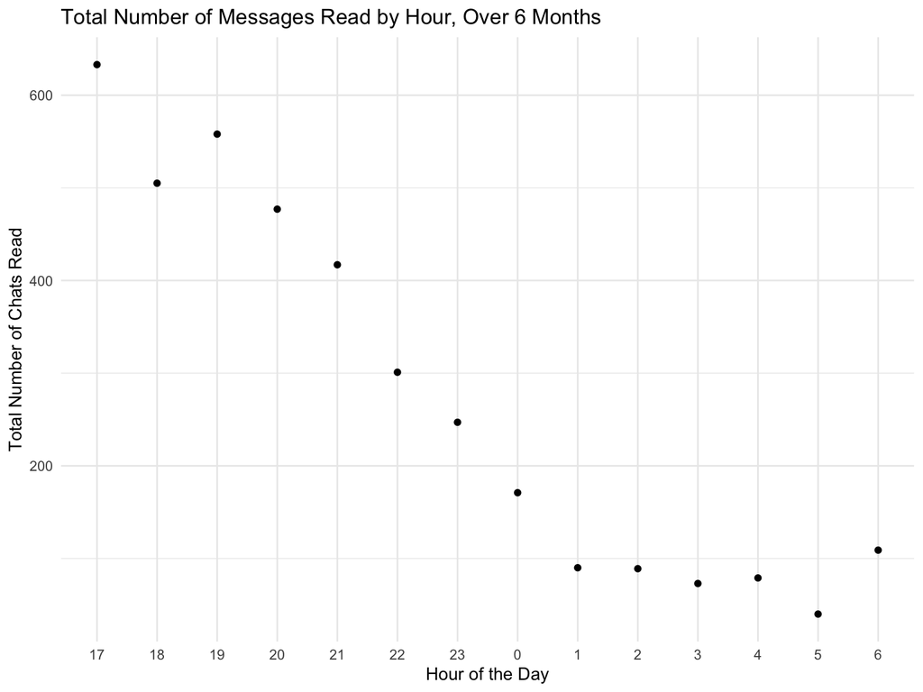

```r
#custom hour order needed for the x-axis
custom_hour_order <- c(17, 18, 19, 20, 21, 22, 23, 0, 1, 2, 3, 4, 5, 6)

#group messages by the hour
chats_by_hour <- chatsoncall |>
  group_by(READ_HOUR_EST) |>
  summarize(number_read_chats = length(unique(READ_TIME_EST)), .groups = 'drop')

#convert to a factor with custom hour order
chats_by_hour <- chats_by_hour |>
  mutate(READ_HOUR_EST = as.numeric(READ_HOUR_EST)) #convert to numeric to match custom_hour_order

chats_by_hour <- chats_by_hour |>
  mutate(READ_HOUR_EST = factor(READ_HOUR_EST, levels = custom_hour_order))

#plot it
ggplot(chats_by_hour, aes(x = READ_HOUR_EST, y = number_read_chats)) +
  geom_point() +
  ggtitle("Total Number of Messages Read by Hour, Over 6 Months ") +
  labs(x = "Hour of the Day", y = "Total Number of Chats Read") +
  theme_minimal()
```

Ideally, ID fellows do not want to be on group chats overnight. To understand if group chats were contributing to the burden of overnight chats, we viewed the number of recipients on the messages they read. Nearly three-quarters of the chats were sent only to the ID fellow on call rather than multiple recipients.

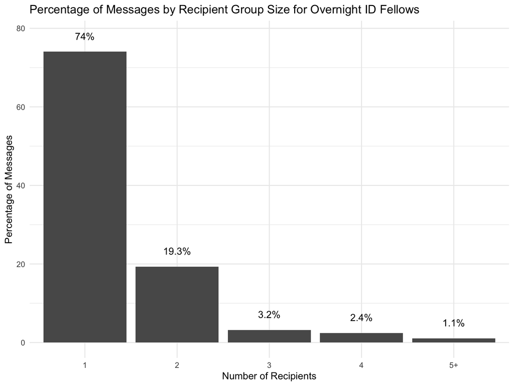

```r
#to get the number of recipients on each message, exclude messages with sender as the reader and total the number of rows with the unique contact_date_real + convo_line

#first filter the chats dataframe for only the overnight chats
chats_all_overnight <- chats |>
  as.data.frame() |>
  filter(SENDER_USER_ID != READER_USER_ID) |>
  mutate(READ_DATE_EST = as.Date(READ_TIME_EST)) |> #date column
  mutate(READ_HOUR_EST = format(READ_TIME_EST, format='%H')) |> #hour column, for visualizations
  filter(as.numeric(READ_HOUR_EST) < 7 | as.numeric(READ_HOUR_EST) > 16) |>
  select(CONTACT_DATE_REAL, CONVO_LINE, TOTAL_CHAT_SENT, READ_DATE_EST, READER_USER_ID, READ_HOUR_EST, READ_TIME_EST, READ_TIME, SENDER_USER_ID)

#now get the recipient counts for each of those overnight chats
recipient_counts <- chats_all_overnight |>
  group_by(TOTAL_CHAT_SENT) |> #unique variable to each message sent
  summarize(count = n(), .groups = 'drop')

#add recipient count for each read message to the overnight chat data
chatsoncall <- chatsoncall |>
  left_join(recipient_counts, by = "TOTAL_CHAT_SENT")

#create a summary of the count of the number of recipients
recipient_counts_summ <- chatsoncall |>
  group_by(count) |>
  summarise(message_count = n(), .groups = 'drop')

#categorize recipient counts into groups for easier visualization
recipient_counts_summ <- recipient_counts_summ |>
  mutate(count_group = case_when(
    count == 1 ~ "1",
    count == 2 ~ "2",
    count == 3 ~ "3",
    count == 4 ~ "4",
    count >= 5 ~ "5+",
    ))

#calculate percentage for each count group
recipient_counts_summ <- recipient_counts_summ |>
  group_by(count_group) |>
  summarize(total_message_count = sum(message_count)) |>
  mutate(percentage = (total_message_count / sum(total_message_count)) * 100)

#graph it!
ggplot(recipient_counts_summ, aes(x = count_group, y = percentage)) +
  geom_bar(stat = "identity") +
  geom_text(aes(label = paste0(round(percentage, 1), "%")), nudge_y = 4) +
  labs(x = "Number of Recipients", y = "Percentage of Messages") +
  ggtitle("Percentage of Messages by Recipient Group Size for Overnight ID Fellows") +
  theme_minimal()
```

## Results

After reviewing the number of messages received each night and the timing of those messages, we wanted to explore how this is impacting the ID fellows on shift.

### Maximum Sleep Time

For the ID fellows who are talking call at home, the overall chat burden is one thing to consider but more importantly, we need to understand the timing of these chats to calculate how much sleep they may be able to get on a call shift.

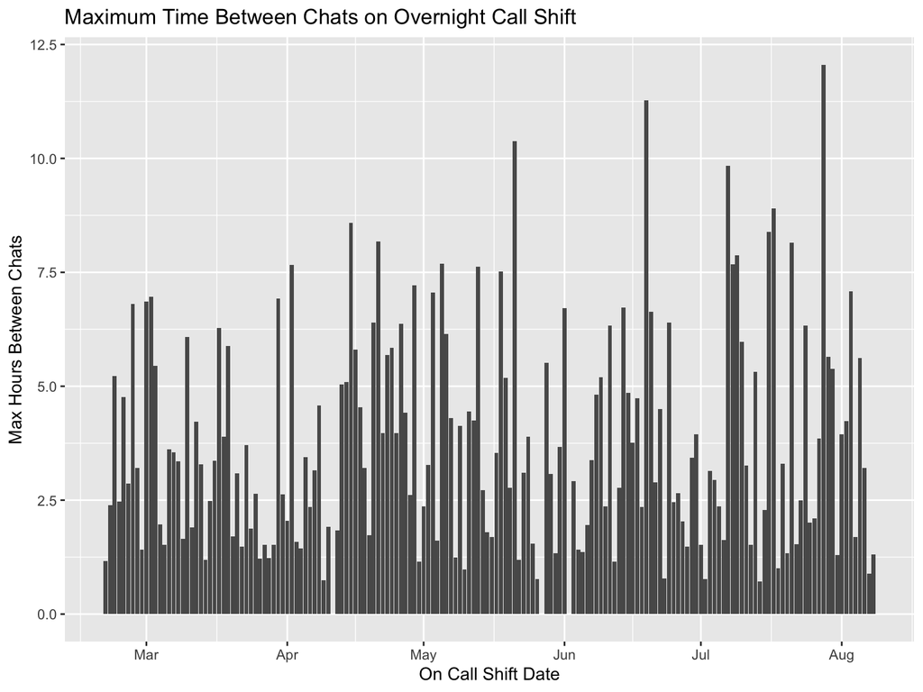

```r
#calculate largest gap in time between chats for each overnight call shift
max_time_between_chats <- chatsoncall |>
  group_by(ON_CALL_DATE) |>
  filter(n() > 1) |> #exclude shifts with only 1 chat so calculations can work
  arrange(READ_TIME_EST) |>  #ensure chats are in time order for each ON_CALL_DATE
  mutate(time_diff = difftime(READ_TIME_EST, lag(READ_TIME_EST), units = "hours")) |>
  summarize(max_time_diff = max(time_diff, na.rm = TRUE))  #calculate the maximum time difference

#bar graph, per call shift
ggplot(max_time_between_chats, aes(x = ON_CALL_DATE, y = max_time_diff)) +
  geom_bar(stat = "identity") +
  ggtitle("Maximum Time Between Chats on Overnight Call Shift") +
  labs(x = "On Call Shift Date", y = "Max Hours Between Chats") +
  scale_y_continuous()
```

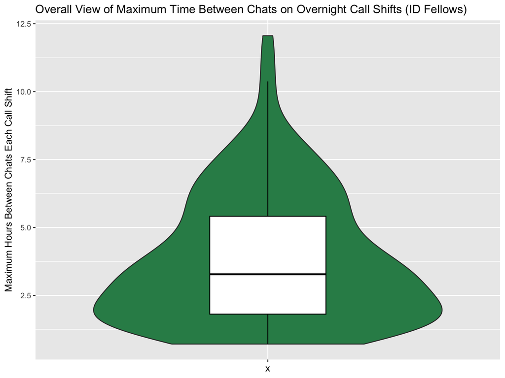

```r
#violin plot to visualize another way
ggplot(max_time_between_chats, aes(x = "", y = max_time_diff)) +
    geom_violin(fill = "seagreen") +
    geom_boxplot(width = 0.3, outlier.shape = NA, color = "black") +
    ggtitle("Overall View of Maximum Time Between Chats on Overnight Call Shifts (ID Fellows)") +
    theme(axis.text.x = element_blank()) +
    labs(y = "Maximum Hours Between Chats Each Call Shift") +
    scale_y_continuous()
```

```r
#mean and sd for maximum time between chats
max_time_between_chats |>
  summarize(mean_max_time_diff = mean(max_time_diff, na.rm = TRUE),
            sd_max_time_diff = sd(max_time_diff, na.rm = TRUE)
  )
```

```
# A tibble: 1 × 2
  mean_max_time_diff sd_max_time_diff
  <drtn>                        <dbl>
1 3.823435 hours                 2.37
```

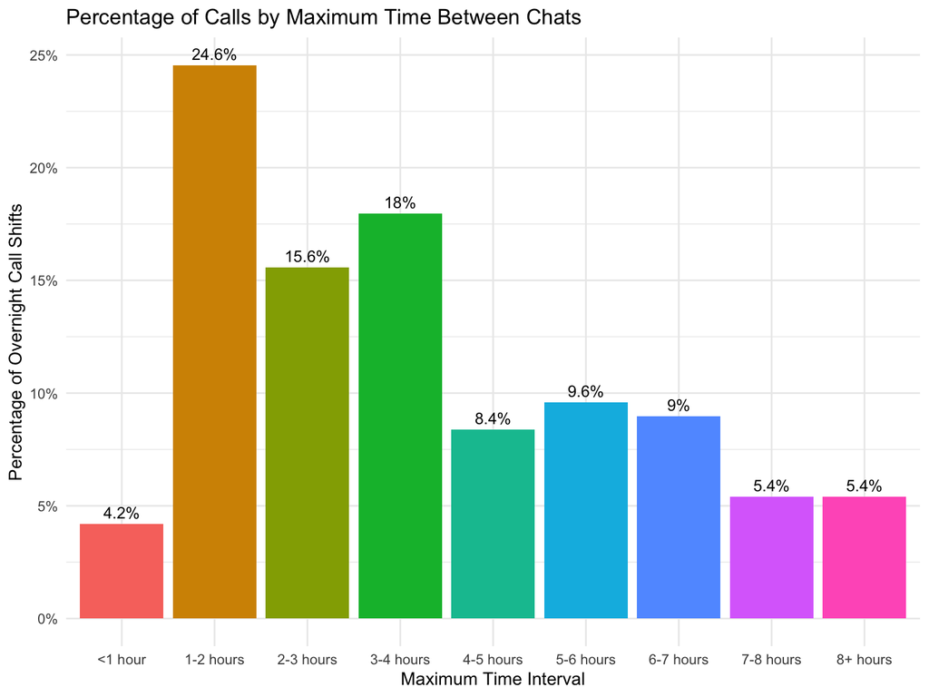

```r
#visualize time intervals to better understand burden
max_time_between_chats <- max_time_between_chats |>
  mutate(
    time_category = case_when(
      max_time_diff < 1 ~ "<1 hour",
      max_time_diff < 2 ~ "1-2 hours",
      max_time_diff < 3 ~ "2-3 hours",
      max_time_diff < 4 ~ "3-4 hours",
      max_time_diff < 5 ~ "4-5 hours",
      max_time_diff < 6 ~ "5-6 hours",
      max_time_diff < 7 ~ "6-7 hours",
      max_time_diff < 8 ~ "7-8 hours",
      max_time_diff > 8 ~ "8+ hours"
    )
  )

#summarize
time_category_summary <- max_time_between_chats |>
  group_by(time_category) |>
  summarise(count = n(), .groups = "drop") |>
  mutate(percentage = (count / sum(count)) * 100)

#view by the hour
ggplot(time_category_summary, aes(x = time_category, y = percentage, fill = time_category)) +
  geom_bar(stat = "identity") +
  geom_text(aes(label = paste0(round(percentage, 1), "%")), vjust = -0.5, size = 3.5) +
  ggtitle("Percentage of Calls by Maximum Time Between Chats") +
  labs(x = "Maximum Time Interval", y = "Percentage of Overnight Call Shifts") +
  scale_y_continuous(labels = scales::percent_format(scale = 1)) +
  theme_minimal() +
  theme(legend.position = "none")
```

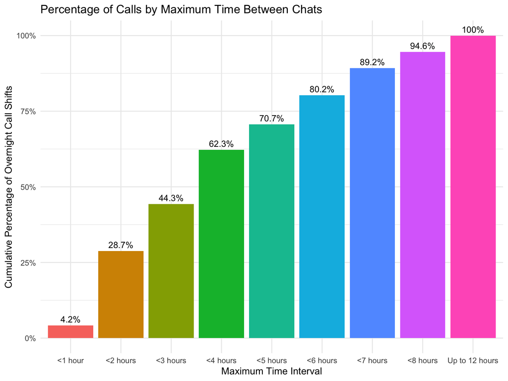

```r
#Mixed feedback on best way to view this information. Cumulative chart included too.
max_time_btwn_chats <- max_time_between_chats |>
  mutate(
    time_category = case_when(
      max_time_diff < 1 ~ "<1 hour",
      max_time_diff < 2 ~ "<2 hours",
      max_time_diff < 3 ~ "<3 hours",
      max_time_diff < 4 ~ "<4 hours",
      max_time_diff < 5 ~ "<5 hours",
      max_time_diff < 6 ~ "<6 hours",
      max_time_diff < 7 ~ "<7 hours",
      max_time_diff < 8 ~ "<8 hours",
      TRUE ~ "Up to 12 hours" #all remaining values
    )
  )

#count totals in each category and calculate cumulative percentages
cumulative_percentages <- max_time_btwn_chats |>
  group_by(time_category) |>
  summarize(count = n(), .groups = "drop") |>
  arrange(match(time_category, c("<1 hour", "<2 hours", "<3 hours", "<4 hours", "<5 hours",
                                 "<6 hours", "<7 hours", "<8 hours", "8+ hours"))) |>
  mutate(
    cumulative_count = cumsum(count),
    cumulative_percentage = 100 * cumulative_count / sum(count)
  )

#view the cumulative chart
ggplot(cumulative_percentages, aes(x = time_category, y = cumulative_percentage, fill = time_category)) +
  geom_bar(stat = "identity") +
  geom_text(aes(label = paste0(round(cumulative_percentage, 1), "%")),
            vjust = -0.5, size = 3.5) +
  ggtitle("Percentage of Calls by Maximum Time Between Chats") +
  labs(x = "Maximum Time Interval", y = "Cumulative Percentage of Overnight Call Shifts") +
  scale_y_continuous(labels = scales::percent_format(scale = 1)) +
  theme_minimal() +
  theme(legend.position = "none")
```

These visualizations help us understand the impact of maximum possible continuous sleep time for the fellows on call. Since they see patients on service the day before and the day after call, there is an incentive to maximize their sleep time to optimize the safe care they provide to patients on the day after call, as well as positively impact their physical and mental health. With interventions to decrease chat burden for ID fellows moving forward, this is the metric we will track most closely.

### Chat Sender Information

To help guide future interventions for optimizing communication through secure chat to ID fellows overnight, we wanted to understand who was sending these chats. The assignment data for one month of chats was obtained for initial exploration. Each user can have multiple roles at a given time and many senders did not have any role assigned at the time that the chat was sent. Due to the complications related to combining the data in a meaningful way without changing the granularity of the final data frame, I instead opted to look directly at the employee table in Epic Clarity to understand who the senders were. This choice did mean that we lost some information, such as the unit a provider was working on at the time of the chat (ie PICU) or their specific role (i.e. charge nurse, bedside nurse). In addition, the employee table is a static snapshot of users at the time the information is obtained, which means there may be some in inaccuracies for those who have changed roles since the time a chat was sent. Despite these drawbacks, we felt that the information gained would lead to insights with which could inform our future interventions.

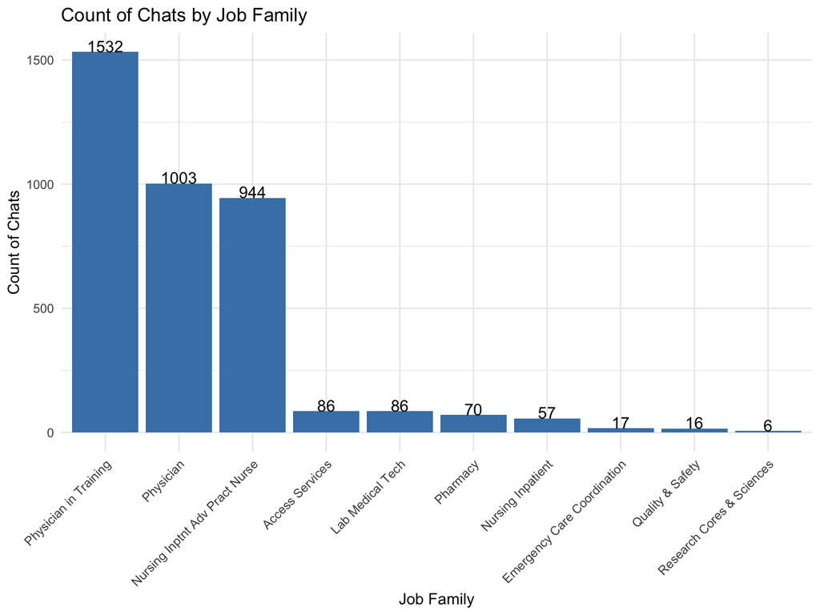

```r
library(writexl)

#get a list of the unique senders (total: 752)
senders <- as.data.frame(unique(chatsoncall$SENDER_USER_ID))

#save as excel document
write_xlsx(senders, "unique_senders.xlsx")

#upload document that includes the employee information
emp_data <- read.csv("~/Documents/Masters of Biomedical Informatics/503 Data Science/Final Project/Employee Data.csv")

#merge tables
chatswithemp <- chatsoncall |>
  left_join(emp_data, by = c("SENDER_USER_ID" = "EMP_ID"))

#group chats by job family
chats_by_job_family <- chatswithemp |>
  group_by(JOB_FAMILY) %>%
  summarize(chat_count = n(), .groups = "drop")

#top roles only (top 10 had > 6 chats)
top_roles <- chats_by_job_family |>
  arrange(desc(chat_count)) |>
  filter(!is.na(JOB_FAMILY)) |>
  filter(JOB_FAMILY != "") |>
  slice_head(n = 10)

#graph by job family
ggplot(top_roles, aes(x = reorder(JOB_FAMILY, -chat_count), y = chat_count)) +
  geom_bar(stat = "identity", fill = "steelblue") +
  ggtitle("Count of Chats by Job Family") +
  labs(x = "Job Family", y = "Count of Chats") +
  geom_text(aes(label = chat_count), vjust = 0, size = 4) +
  theme_minimal() +
  theme(axis.text.x = element_text(angle = 45, hjust = 1))
```

It looks like a vast majority of these chats are sent by physicians and APPs. To better understand the percentage of chats from those roles, we can do additional calculations.

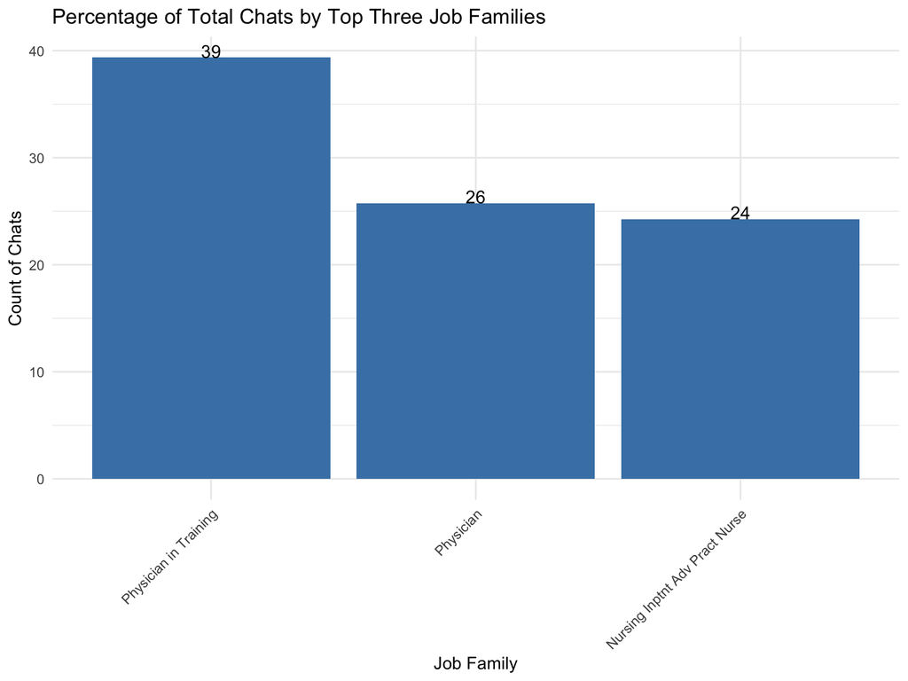

```r
#define the roles we're interested in
roles_of_interest <- c("Physician in Training", "Physician", "Nursing Inptnt Adv Pract Nurse")

#filter for rows with the roles we're interested in
filtered_roles <- chatswithemp |>
  filter(JOB_FAMILY %in% roles_of_interest) |>
  count(JOB_FAMILY)

#get the total number of chats for denominator
total_chat_count <- chatsoncall |>
  count()

#calculate the percentage
role_chat_count <- filtered_roles |>
  mutate(percentage = n / total_chat_count$n * 100)

#graph by role chat count percentage
ggplot(role_chat_count, aes(x = reorder(JOB_FAMILY, -percentage) , y = percentage)) +
  geom_bar(stat = "identity", fill = "steelblue") +
  ggtitle("Percentage of Total Chats by Top Three Job Families") +
  labs(x = "Job Family", y = "Count of Chats") +
  geom_text(aes(label = round(percentage, 0)), vjust = 0, size = 4) +
  theme_minimal() +
  theme(axis.text.x = element_text(angle = 45, hjust = 1))
```

```r
sum(role_chat_count$percentage)
```

```
[1] 89.36553
```

## Conclusion

The analysis of overnight call secure chat data for ID fellows highlights several key patterns in communication. The daily message count by overnight shift displays consistent activity across the observed six month time period, with variability likely reflecting clinical demands. This visualization underscores the sustained workload ID fellows experience during these shifts.

The hourly distribution of chat messages read by ID fellows during overnight call shifts highlights a distinct trend in workload over time. The data shows the highest volume of chats occurs during the early hours of the shift, particularly between 5 PM and 10 PM, with the peak at the start of the shift at 5 PM. After this initial surge, chat volume decreases steadily through the night, reaching its lowest point between 3 to 5 AM, before increasing slightly in the last hour of the call shift. This pattern suggests that the initial hours of call shifts are particularly demanding, requiring fellows to manage a significant volume of communication. Understanding this distribution can inform strategies to better support fellows during high-demand periods and optimize team workflows during overnight shifts.

The distribution of maximum time intervals between chats shows that more than one quarter of the shifts go less than 2 hours maximum between chats for the entire shift. Over 60% of calls have a maximum interval of less than 4 hours between messages. This finding suggests a high frequency of interruptions during overnight call shifts, with significant implications for workflow and rest opportunities.

## Next Steps

We have met with a lead fellow for infectious disease to discuss our findings and brainstorm possible interventions to improve their secure chat experience. Given the large number of chats at the start of the shift, there may be improved in person communication on specific services that can alleviate some of the chat burden. They will also focus education on physicians in training (residents). They have implemented messaging with instructions on when to reach out to the antimicrobial stewardship team or infection prevention (instead of infectious disease fellows) and will monitor for improvements there.

There are three fellowship-supported services at the hospital that take home call. This analysis will be run for the other two services (endocrinology and rheumatology) and a comparative analysis will be done between the different clinical services. We also plan to dive deeper into understanding the group chats, looking at length of conversation, timing of conversation, and senders to help target interventions at decreasing group chats. Lastly, there is a wealth of data in the actual text of the chats that we would love to explore in the future.

## References

1. Hoffman JM, Keeling NJ, Forrest CB, et al. Priorities for pediatric patient safety research. *Pediatrics.* 2019;143(2).
2. Dixon-Woods M. Why is patient safety so hard? A selective review of ethnographic studies. *J Health Serv Res Policy.* 2010;15:11-16.
3. Khan A, Furtak SL, Melvin P, Rogers JE, Schuster MA, Landrigan CP. Parent-reported errors and adverse events in hospitalized children. *JAMA Pediatr.* 2016;170(4):e154608.
4. Leonard M, Graham S, Bonacum D. The human factor: the critical importance of effective teamwork and communication in providing safe care. *Qual Saf Health Care.* 2004;13 Suppl 1:i85-90.
5. Fortescue EB, Kaushal R, Landrigan CP, et al. Prioritizing strategies for preventing medication errors and adverse drug events in pediatric inpatients. *Pediatrics.* 2003;111:722-729
6. Hagedorn PA, Singh A, Luo B, Bonafide CP, Simmons JM. Secure text messaging in healthcare: latent threats and opportunities to improve patient safety. *J Hosp Med.* 2020;15(6):378-380.